# Geospatial data analysis in #rstats. Part 2

**Keywords:** geostatistics, R, soil science

Continuing our series on geospatial analysis we are doing to dive into spatial statistics expanding analyses of spatial patterns. In my [prior post](https://swampthingpaul.github.io/blog/geospatial-data-analysis-in-rstats.-part-1/) I presented spatial interpolation including kriging. Just like in the last post I will be using [tmap](https://swampthingpaul.github.io/blog/mapping-in-rstats/) to display our geospatial data. Also like in the last post I will be using a “fake” dataset from real stations with a randomly generated imposed spatial gradient for demonstration purposes.

First lets load the necessary R-packages/libraries.

```r
# Libraries
library(sp)
library(rgdal)
library(rgeos)
library(maptools)
library(raster)
library(tmap)
library(tmaptools)

library(spdep)
library(spatstat)
```

Here is our data from the [prior post](https://swampthingpaul.github.io/blog/geospatial-data-analysis-in-rstats.-part-1/)…remember?

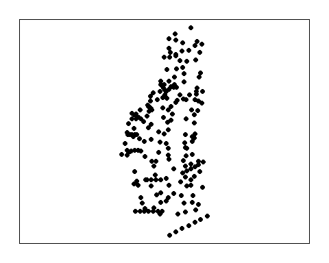

## Average Nearest-Neighbor

An average nearest neighbor (ANN) analysis measures the average distance from each point in the study area to its nearest point. Average nearest neighbor is exactly what is says it is the average distance between points (or neighbors) the ultimate analysis involves determining a matrix of distances between points. When plotting ANN as a function of neighbor order it provides some insight into the spatial structure of the data (Gimond 2018).

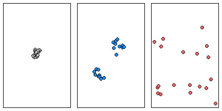

Three different point patterns: a single cluster, a dual cluster and a randomly scattered pattern.

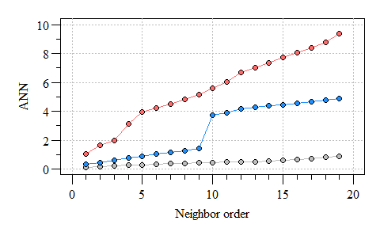

Three different ANN vs. neighbor order plots. The black ANN line is for the first point pattern (single cluster); the blue line is for the second point pattern (double cluster) and the red line is for the third point pattern.

As you can see the more clustered the points the consistent the distance between neighbors. As points become more dispersed, the distances vary from neighbor-to-neighbor, the abrupt change in ANN observed in the clustered points is an indicator of groups/clusters of points and the gradual increase in ANN indicates more-or-less random distribution of points.

What does the ANN network look like for our data? Remember our thessian polygon of the monitoring network from the last [post](https://swampthingpaul.github.io/blog/geospatial-data-analysis-in-rstats.-part-1/)?

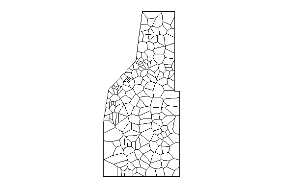

Thessian polygons clipped to study area.

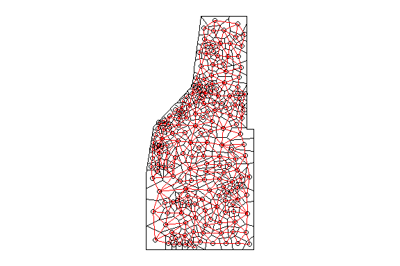

Thessian polygons clipped to the study area with neighborhood network.

```r
#th.dat is the thessian polygons above.
w=poly2nb(th.dat, row.names=th.dat$Site);#construct the neighbours list.

par(mar=rep(0.5,4),oma=rep(0,4));
plot(th.dat)
plot(w,coordinates(th.dat), col='red', lwd=0.5,add=T)
```

The `poly2nb()` function builds a neighbors list based on regions with a contiguous boundary that is sharing one or more boundary point. However, this same function can be completed for points as well. Much like the `poly2nb()` function builds the neighbors list, the `knearneigh()` function also builds a list using a specified number of neighbors to consider (i.e k). As k increases (i.e. data points), more neighbors are considered and thereby influencing the estimated mean distance between nearest neighbors. As a demonstration here is what the network looks like with only six neighbors considered.

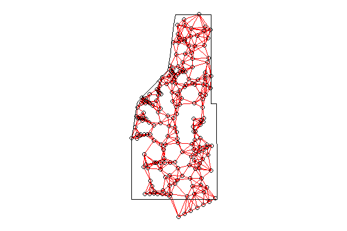

```r
#th.dat is the thessian polygons above.

w2=knn2nb(knearneigh(sp.dat,k=6))
w2=nb2listw(w2)

par(mar=rep(0.5,4),oma=rep(0,4));
plot(w2,coordinates(sp.dat),col="red")
plot(study.area,add=T)
```

As you can see the point-based ANN with only six neighbors considered results in a different network. But what affect does the k number have on ANN?

```r
ANN=apply(nndist(as(sp.dat,"ppp"), k=1:202),2,FUN=mean)
```

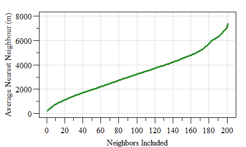

Average Nearest Neighbour as a function of neighbor included.

Selection of a K value can also be corrected for various edge corrections, some of you may be heard of *Ripley’s K*-function (Ripley 1977). For purposes of th is post we will not delve into this aspect of spatial analysis however if your intrested and eager to learn Gimond (2018) introduces some of these concepts in detail.

For purposes of this post we are going with a very simple neighbor list (i.e. `w` variable above) using the thessian polygons to estimate a spatial weight within the network. This neighbor list comes into play in a little bit. Maybe we can dig into the *Ripley’s K*-function in a future post.

## Spatial Autocorrelation

Most if not all field data can be characterized as spatial data, especially in ecology. If something is sampled at a particular location there is a spatial component to the data. As such there are some spatial specific statistics that be applied to spatial data to explain how the data relates to the world. One such statistic is spatial autocorrelation.

Spatial autocorrelation measures the degree to which a phenomenon of interest is correlated to itself in space. This statistical analysis evaluates whether the observed value of a variable at one location is independent of values of that variability at neighboring locations.

- Positive spatial autocorrelation indicates similar values appear close to each other (i.e. clustered in space).
- Negative spatial autocorrelation indicates that neighboring values are dissimilar (i.e. dispersed in space).
- No spatial autocorrelation indicates that the spatial pattern is completely random.

Moran’s *I* is the most common spatial autocorrelation test however other tests are available (i.e. [Geary’s C](https://en.wikipedia.org/wiki/Geary%27s_C), [Join-Count](https://mltconsecol.github.io/TU_LandscapeAnalysis_Documents/Assignments_web/Assignment06_Autocorrelation.pdf), etc.) each have a specific application much like the different correlation analyses (i.e. Pearson’s, Spearman, Kendall, etc.). Moreover the spatial autocorrelation analysis of spatial data is relatively straight forward.

Spatial analyses can be expressed in a *“Global”* or *“Local”* context. Spatial autocorrelation is no different. Global spatial analysis evaluates the data across the entire dataset (i.e. study area) and assumes homogeneity across the dataset. If the data is spatially heterogeneous or also referred to as inhomogeneous local analyses can be applied. For instance if no global spatial autocorrelation is detected autocorrelation can be tested at the local (i.e. individual spatial units). Moran’s *I* uses local indicators of spatial association to evaluate data at the local and global levels where the global analysis is the sum of local *I* values.

[Gimond (2018)](https://mgimond.github.io/Spatial/point-pattern-analysis-in-r.html) and [Baddeley (2008)](https://training.fws.gov/courses/references/tutorials/geospatial/CSP7304/documents/PointPatterTutorial.pdf) provides an excellent step-by-step tutorial on point pattern analysis, the basis of spatial homogeneity. I highly recommend taking a look!!

Moran’s I can be calculated long-hand or using the `spdep` r-package.

Local Moran’s *I* spatial autocorrelation statistic ($I_i$), also sometimes referred to as Anselin Local Moran’s *I* (Anselin 1995) and is calculated by:

$$I_{i} = \frac{n}{\sum_{i=1}^n (y_i - \bar{y})^2} \times \frac{\sum_{i=1}^n \sum_{j=1}^n w_{ij}(y_i - \bar{y})(y_j - \bar{y})}{\sum_{i=1}^n \sum_{j=1}^n w_{ij}}$$
Where $y_{i}$ is the attribute feature (i.e. soil total phosphorus in our case), $\bar{y}$ is the arithmetic mean across the entire study area/spatial unit, $w_{ij}$ is the spatial weight between $i$ and $j$ and $n$ is the total number of features.

As alluded to early in addition to a local statistic we also have a Global metric. Global Moran’s *I* is merely the sum of the local values divided by the total number of features ($n$)

$$I = \sum_{i=1} \frac{I_{i}}{n}$$

As introduced above, if the Moran’s I statistic is positive indicates that a feature has neighboring features with similarly high or low attribute values; this feature is part of a cluster at the local level. Alternatively if the Moran’s I statistic is negative it indicates that a feature has neighboring features with dissimilar values.Moran’s I statistic is a relative metric and therefore a $z$score and $\rho$-value can also be calculated to determine statistical significance.

Enough talk, lets jump into `R`!!

Calculating Moran’s I statistic by hand. Code adapted from [rspatial.org](https://rspatial.org/analysis/3-spauto.html).

```r
wm=nb2mat(w, style='B');#spatial weights matrix

n=length(th.dat$TP_mgkg);# total number of features
y=th.dat$TP_mgkg;# attribute feature
ybar=mean(th.dat$TP_mgkg);# mean attribute feature across project area
dy=y - ybar;# residual value

yi=rep(dy, each=n);# a list of yi
yj=rep(dy);# a list of yj
yiyj= yi * yj;# cross product of yi and yj

pm=matrix(yiyj,ncol=n);# a matrix of cross products
pmw=pm * wm;# cross products with spatial weights (w value from above)
           # set to zero the value for the pairs that are not adjacent

spmw=sum(pmw,na.rm=T);#
smw=sum(wm); #Sum of spatial weights
sw=spmw / smw

var=n / sum(dy^2);# variance in y

MI=var * sw;# Moran's I
MI
```

```
## [1] 0.5790256
```

First we need to prep the spatial weights, this time in the form of a list rather than a matrix.

```r
ww <-  nb2listw(w, style='B');# puts w in a list rather than a matrix
ww
```

```
## Characteristics of weights list object:
## Neighbour list object:
## Number of regions: 194
## Number of nonzero links: 1052
## Percentage nonzero weights: 2.795196
## Average number of links: 5.42268
##
## Weights style: B
## Weights constants summary:
##     n    nn   S0   S1    S2
## B 194 37636 1052 2104 24592
```

Now we can use the `moran()` function in the `spdep` package. In this function we plug in the data, number of features (i.e. n) and the global spatial weights $S_0$ (`smw` variable in the long hand example above).

```r
MI2=moran(th.dat$TP_mgkg, ww, n=length(ww$neighbours), S0=Szero(ww))
MI2
```

```
## $I
## [1] 0.5790256
##
## $K
## [1] 3.243009
```

## References

- Anselin L (1995) Local Indicators of Spatial Association—LISA. Geographical Analysis 27:93–115.
- Baddeley A (2008) Analysing spatial point patterns in R. CSIRO. 171.
- Gimond M (2018) Intro to GIS and Spatial Analysis.
- Ripley BD (1977) Modelling Spatial Patterns. Journal of the Royal Statistical Society: Series B (Methodological) 39:172–192.